# Time Series Analysis

Road Casualities in Great Britain

Mashudali Moinuddin

March 2024

### Brief Overview and some R

UKDriverDeaths is a time series giving the monthly totals of car drivers in Great Britain killed or seriously injured Jan 1969 to Dec 1984. They later introduced the same data with multiple time series in which was called Seatbelts. In this time series analysis we will only be focusing on original UKDriverDeaths data set.

```r
UKDriverDeaths #dataset
```

```
##       Jan  Feb  Mar  Apr  May  Jun  Jul  Aug  Sep  Oct  Nov  Dec
## 1969 1687 1508 1507 1385 1632 1511 1559 1630 1579 1653 2152 2148
## 1970 1752 1765 1717 1558 1575 1520 1805 1800 1719 2008 2242 2478
## 1971 2030 1655 1693 1623 1805 1746 1795 1926 1619 1992 2233 2192
## 1972 2080 1768 1835 1569 1976 1853 1965 1689 1778 1976 2397 2654
## 1973 2097 1963 1677 1941 2003 1813 2012 1912 2084 2080 2118 2150
## 1974 1608 1503 1548 1382 1731 1798 1779 1887 2004 2077 2092 2051
## 1975 1577 1356 1652 1382 1519 1421 1442 1543 1656 1561 1905 2199
## 1976 1473 1655 1407 1395 1530 1309 1526 1327 1627 1748 1958 2274
## 1977 1648 1401 1411 1403 1394 1520 1528 1643 1515 1685 2000 2215
## 1978 1956 1462 1563 1459 1446 1622 1657 1638 1643 1683 2050 2262
## 1979 1813 1445 1762 1461 1556 1431 1427 1554 1645 1653 2016 2207
## 1980 1665 1361 1506 1360 1453 1522 1460 1552 1548 1827 1737 1941
## 1981 1474 1458 1542 1404 1522 1385 1641 1510 1681 1938 1868 1726
## 1982 1456 1445 1456 1365 1487 1558 1488 1684 1594 1850 1998 2079
## 1983 1494 1057 1218 1168 1236 1076 1174 1139 1427 1487 1483 1513
## 1984 1357 1165 1282 1110 1297 1185 1222 1284 1444 1575 1737 1763
```

```r
head(UKDriverDeaths) # This will display first few samples
```

```
## [1] 1687 1508 1507 1385 1632 1511
```

```r
time(UKDriverDeaths) #This will display times of the data
```

```
##           Jan      Feb      Mar      Apr      May      Jun      Jul      Aug
## 1969 1969.000 1969.083 1969.167 1969.250 1969.333 1969.417 1969.500 1969.583
## 1970 1970.000 1970.083 1970.167 1970.250 1970.333 1970.417 1970.500 1970.583
## 1971 1971.000 1971.083 1971.167 1971.250 1971.333 1971.417 1971.500 1971.583
## 1972 1972.000 1972.083 1972.167 1972.250 1972.333 1972.417 1972.500 1972.583
## 1973 1973.000 1973.083 1973.167 1973.250 1973.333 1973.417 1973.500 1973.583
## 1974 1974.000 1974.083 1974.167 1974.250 1974.333 1974.417 1974.500 1974.583
## 1975 1975.000 1975.083 1975.167 1975.250 1975.333 1975.417 1975.500 1975.583
## 1976 1976.000 1976.083 1976.167 1976.250 1976.333 1976.417 1976.500 1976.583
## 1977 1977.000 1977.083 1977.167 1977.250 1977.333 1977.417 1977.500 1977.583
## 1978 1978.000 1978.083 1978.167 1978.250 1978.333 1978.417 1978.500 1978.583
## 1979 1979.000 1979.083 1979.167 1979.250 1979.333 1979.417 1979.500 1979.583
## 1980 1980.000 1980.083 1980.167 1980.250 1980.333 1980.417 1980.500 1980.583
## 1981 1981.000 1981.083 1981.167 1981.250 1981.333 1981.417 1981.500 1981.583
## 1982 1982.000 1982.083 1982.167 1982.250 1982.333 1982.417 1982.500 1982.583
```

[output cut: 19 more lines]

```r
class(UKDriverDeaths) # data class should be time series
```

```
## [1] "ts"
```

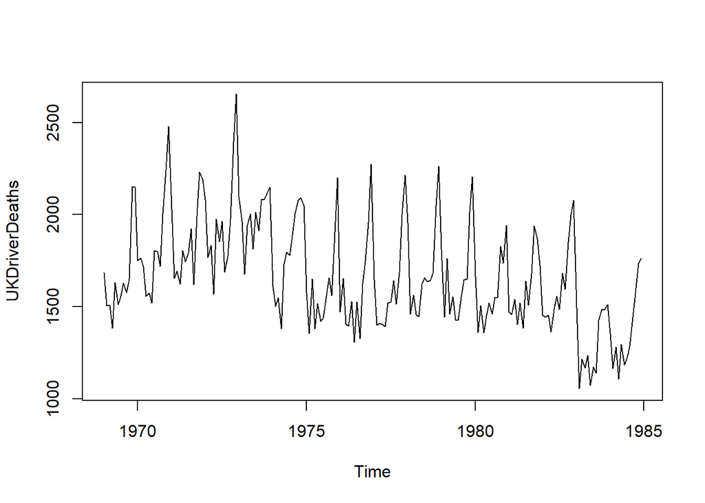

```r
plot(UKDriverDeaths)  #plot of the graph
```

The plot of the graph tells us that there is no consistent or clear trend. There is fluctuations in the total number of casualties over the year. and towards the end it was a sudden huge drop this might be possible because of the compulsory wearing of seat belt law introduced on 31 January 1983 this have been visible from the graph.

### Detrending

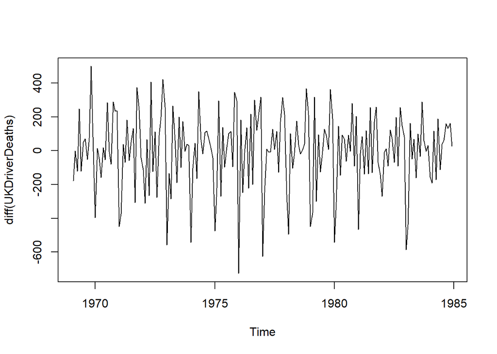

```r
plot(diff(UKDriverDeaths)) #plot of the differences to detrend the data if there is any
```

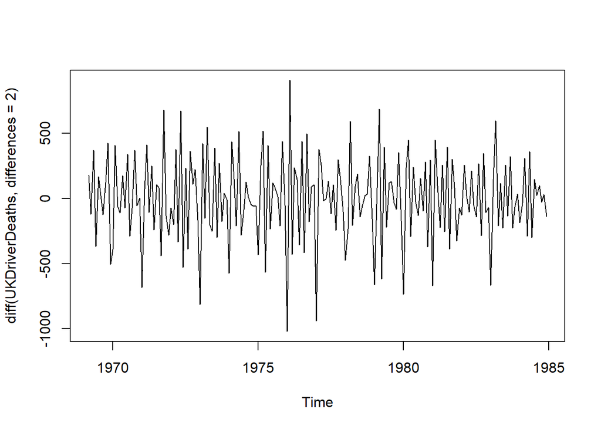

```r
plot(diff(UKDriverDeaths,differences = 2)) #plot of the 2 differences to detrend the data if there is any
```

when we plot difference graph it shows that difference of 2 is much more noisier than the normal difference one.But overall shape of all the graph is similar. This two plots de-trends the data if there is any.